# Foetal Health using CTG

Analysis, Classification and Prediction of foetal health through supervised learning models.

Daniele Buson, Sasa Ljubisavljevic, Jonas Renfer

03 aprile 2023

## 1. Introduction

Reduction of child mortality is reflected in several of the United Nations’ Sustainable Development Goals and is a key indicator of human progress. In the last three decades, the world made remarkable progress in child survival. In the 90’s, 1 in 11 children died before the age of five. Nowadays, the ratio is 1 in 26 children. (1) The UN expects to lower this percentage to 25 deaths in 1000 births by 2030. Another aspect, alongside this, that is crucial in the Sustainable Development Goals is maternal mortality. About 287000 women died during and following pregnancy and childbirth in 2020. Almost 95% of all maternal deaths occurred in low and lower middle-income countries in 2020, and most could have been prevented. (2) In this context, Cardiotocography (CTGs) is a simple and cost accessible option to assess foetal health, allowing healthcare professionals to take action in order to prevent child and maternal mortality. The equipment itself works by sending ultrasound pulses and reading its response, thus shedding light on foetal heart rate (FHR), foetal movements, uterine contractions and more.

## 2. Dataset Overview

In the section below is shown an overview of the data. The subsection 2.1 shows the table and the key figures obtained through the R-command “summary”. In the 2.2 a correlation plot is presented, helping us understand if there is some form of dependence between the data.

### 2.1 Table and Summary

The dataset columns are defined as follow:

1. baseline.value : baseline foetal heart rate
2. accelerations : number of accelerations per second
3. fetal_movement : number of foetal movements per second
4. uterine_contractions : number of uterine contractions per second
5. light_decelerations : number of LDs per second (3)
6. severe_decelerations : number of SDs per second (3)
7. prolonged_decelarations: number of PDs per second (3)
8. abnormal_short_term_variability : percentage of time with abnormal short term variability (4)
9. mean_value_of_short_term_variability : mean value of short term variability (4)
10. percentage_of_time_with_abnormal_long_term_variability : percentage of time with abnormal long term variability (4)
11. mean_of_long_term_variability : mean value of long term variability (4)
12. histogram_width : width of the histogram made using all values from a record
13. histogram_min : histogram minimum value
14. histogram_max : histogram maximum value
15. histogram_number_of_peaks : number of peaks in the exam histogram
16. histogram_number_of_zeros : number of zeroes in the exam histogram
17. histogram_mode : histogram mode
18. histogram_mean : histogram mean
19. histogram_median : histogram median
20. histogram_variance : histogram variance
21. histogram_tendency : histogram trend
22. fetal_health : foetal health, 1 = normal, 2 = suspect, 3 = pathological

```
##   baseline.value accelerations fetal_movement uterine_contractions
## 1            120         0.000              0                0.000
## 2            132         0.006              0                0.006
## 3            133         0.003              0                0.008
## 4            134         0.003              0                0.008
## 5            132         0.007              0                0.008
## 6            134         0.001              0                0.010
##   light_decelerations severe_decelerations prolongued_decelerations
## 1               0.000                    0                    0.000
## 2               0.003                    0                    0.000
## 3               0.003                    0                    0.000
## 4               0.003                    0                    0.000
## 5               0.000                    0                    0.000
## 6               0.009                    0                    0.002
##   abnormal_short_term_variability mean_value_of_short_term_variability
```

[output cut: 41 more lines]

```
##  baseline.value  accelerations      fetal_movement     uterine_contractions
##  Min.   :106.0   Min.   :0.000000   Min.   :0.000000   Min.   :0.000000
##  1st Qu.:126.0   1st Qu.:0.000000   1st Qu.:0.000000   1st Qu.:0.002000
##  Median :133.0   Median :0.002000   Median :0.000000   Median :0.004000
##  Mean   :133.3   Mean   :0.003178   Mean   :0.009481   Mean   :0.004366
##  3rd Qu.:140.0   3rd Qu.:0.006000   3rd Qu.:0.003000   3rd Qu.:0.007000
##  Max.   :160.0   Max.   :0.019000   Max.   :0.481000   Max.   :0.015000
##  light_decelerations severe_decelerations prolongued_decelerations
##  Min.   :0.000000    Min.   :0.000e+00    Min.   :0.0000000
##  1st Qu.:0.000000    1st Qu.:0.000e+00    1st Qu.:0.0000000
##  Median :0.000000    Median :0.000e+00    Median :0.0000000
##  Mean   :0.001889    Mean   :3.293e-06    Mean   :0.0001585
##  3rd Qu.:0.003000    3rd Qu.:0.000e+00    3rd Qu.:0.0000000
##  Max.   :0.015000    Max.   :1.000e-03    Max.   :0.0050000
##  abnormal_short_term_variability mean_value_of_short_term_variability
##  Min.   :12.00                   Min.   :0.200
##  1st Qu.:32.00                   1st Qu.:0.700
##  Median :49.00                   Median :1.200
##  Mean   :46.99                   Mean   :1.333
##  3rd Qu.:61.00                   3rd Qu.:1.700
##  Max.   :87.00                   Max.   :7.000
##  percentage_of_time_with_abnormal_long_term_variability
##  Min.   : 0.000
##  1st Qu.: 0.000
##  Median : 0.000
##  Mean   : 9.847
##  3rd Qu.:11.000
##  Max.   :91.000
##  mean_value_of_long_term_variability histogram_width  histogram_min
##  Min.   : 0.000                      Min.   :  3.00   Min.   : 50.00
##  1st Qu.: 4.600                      1st Qu.: 37.00   1st Qu.: 67.00
##  Median : 7.400                      Median : 67.50   Median : 93.00
##  Mean   : 8.188                      Mean   : 70.45   Mean   : 93.58
##  3rd Qu.:10.800                      3rd Qu.:100.00   3rd Qu.:120.00
##  Max.   :50.700                      Max.   :180.00   Max.   :159.00
##  histogram_max histogram_number_of_peaks histogram_number_of_zeroes
##  Min.   :122   Min.   : 0.000            Min.   : 0.0000
##  1st Qu.:152   1st Qu.: 2.000            1st Qu.: 0.0000
##  Median :162   Median : 3.000            Median : 0.0000
##  Mean   :164   Mean   : 4.068            Mean   : 0.3236
##  3rd Qu.:174   3rd Qu.: 6.000            3rd Qu.: 0.0000
##  Max.   :238   Max.   :18.000            Max.   :10.0000
##  histogram_mode  histogram_mean  histogram_median histogram_variance
##  Min.   : 60.0   Min.   : 73.0   Min.   : 77.0    Min.   :  0.00
##  1st Qu.:129.0   1st Qu.:125.0   1st Qu.:129.0    1st Qu.:  2.00
##  Median :139.0   Median :136.0   Median :139.0    Median :  7.00
##  Mean   :137.5   Mean   :134.6   Mean   :138.1    Mean   : 18.81
##  3rd Qu.:148.0   3rd Qu.:145.0   3rd Qu.:148.0    3rd Qu.: 24.00
##  Max.   :187.0   Max.   :182.0   Max.   :186.0    Max.   :269.00
##  histogram_tendency  fetal_health
##  Min.   :-1.0000    Min.   :1.000
##  1st Qu.: 0.0000    1st Qu.:1.000
##  Median : 0.0000    Median :1.000
##  Mean   : 0.3203    Mean   :1.304
##  3rd Qu.: 1.0000    3rd Qu.:1.000
##  Max.   : 1.0000    Max.   :3.000
```

The reader will find more deep insights on the columns in the next section (3. EDA).

### 2.2 Correlation plot

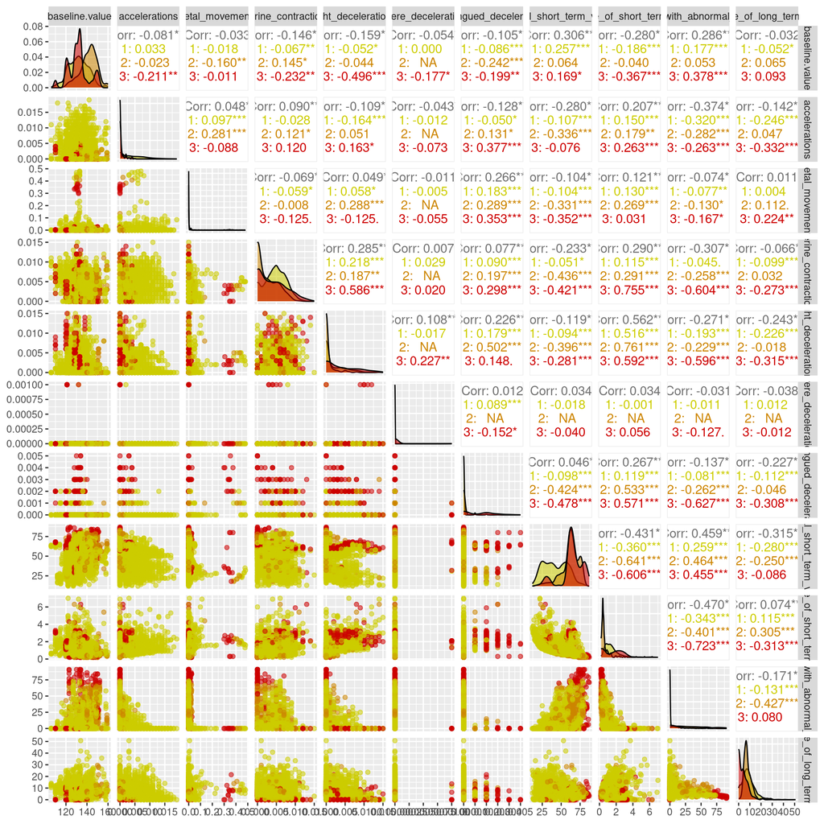

The correlation plot below resembles a square matrix and it can be divided into three parts. Scatter plots of each pair of numeric variables are drawn on the left part of the figure. Pearson correlation is displayed on the right. Variable distribution is available on the diagonal. In this case, the presence of three different colours is due to the fact that we are considering the three possible categories of foetal health (normal, suspect and pathological). We are going to dive more deeply into the densities in the next section, the EDA.

## 3. EDA

In the EDA (exploratory data analysis) we are going to focus on the distribution of some variables. In particular, we would like to group variables by categories. The reader can find below the six sections that we are going to discuss:

1. Heart Rate Baseline
2. Accelerations and Decelerations
3. Foetal and Uterine Movements
4. Short Term Variability VS Long Term Variability
5. Heart Rate Histogram
6. Foetal Health

### 3.1 Heart Rate Baseline

Normal baseline FHR ranges from 110 to 160 beats/min. A baseline change is interpreted as one that persists for 10 minutes or more and occurs between or in the absence of contractions. An FHR of less than 110 beats/min is considered bradycardia. FHR is a function of the autonomic nervous system. The vagus nerve provides an inhibitory affect, whereas the sympathetic nervous system provides an excitatory influence. As the gestation advances, the vagal system gains dominance, resulting in a gradual decrease in the baseline. Stressful events such as hypoxia, uterine contractions, and head compression evoke a baroreceptor reflex, with resulting peripheral vasoconstriction and hypertension causing bradycardia.(6)

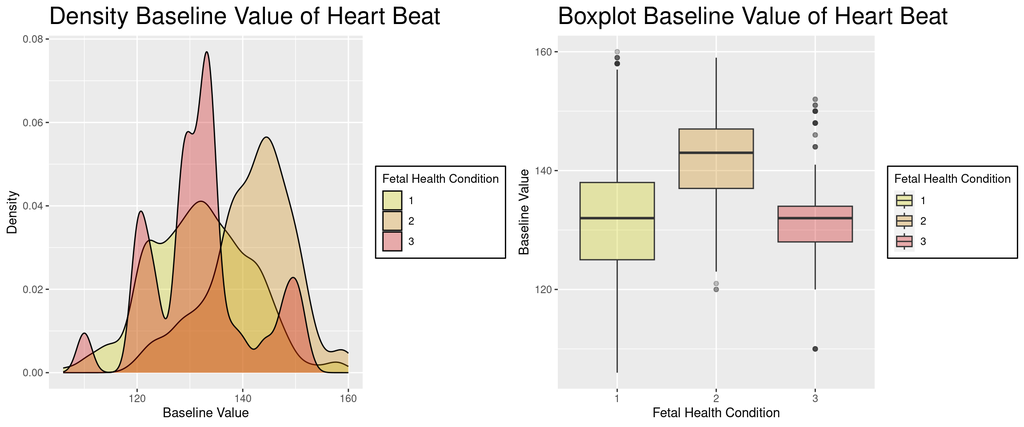

In this case, the graphs seem to be quite eloquent. In fact, in the density plot, the reader can understand how the normal cases have a distribution that is symmetrical to respect to the median. The suspect and pathological have different density distributions. The suspect cases tend to be on the right side (left skewed, average higher than the normal cases). For what concerns the pathological foetus, it is only possible to notice that the distribution has four peaks. The “highest” one is in the middle, respecting the estimated median. However, two peaks are located on the edges. More insights on the distributions can be spotted in the boxplot on the right.

### 3.2 Accelerations and Decelerations

Accelerations are transient increases in the FHR. They are usually associated with foetal movement, vaginal examinations, uterine contractions, umbilical vein compression, foetal scalp stimulation or even external acoustic stimulation. The presence of accelerations is considered a reassuring sign of foetal well-being. An acceleration pattern preceding or following a variable deceleration (the “shoulders” of the deceleration) is seen only when the foetus is not hypoxic. Accelerations are the basis for the nonstress test (NST). The presence of at least two accelerations, each lasting for 15 or more seconds above baseline and peaking at 15 or more bpm, in a 20-minute period is considered a reactive NST. Early decelerations (also light decelerations) are caused by foetal head compression during uterine contraction, resulting in vagal stimulation and slowing of the heart rate. This type of deceleration has a uniform shape, with a slow onset that coincides with the start of the contraction and a slow return to the baseline that coincides with the end of the contraction. Variable decelerations (also severe decelerations) are shown by an acute fall in the FHR with a rapid downslope and a variable recovery phase. They are characteristically variable in duration, intensity and timing. Their graphs resemble the letter “U,” “V” or “W” and may not bear a constant relationship to uterine contractions. They are the most commonly encountered patterns during labor and occur frequently in patients who have experienced premature rupture of membranes and decreased amniotic fluid volume. Variable decelerations are caused by compression of the umbilical cord. Late decelerations (also prolongued) are associated with uteroplacental insufficiency and are provoked by uterine contractions. Any decrease in uterine blood flow or placental dysfunction can cause late decelerations. Maternal hypotension and uterine hyperstimulation may decrease uterine blood flow. Postdate gestation, preeclampsia, chronic hypertension and diabetes mellitus are among the causes of placental dysfunction. Other maternal conditions such as acidosis and hypovolemia associated with diabetic ketoacidosis may lead to a decrease in uterine blood flow, late decelerations and decreased baseline variability. (7)

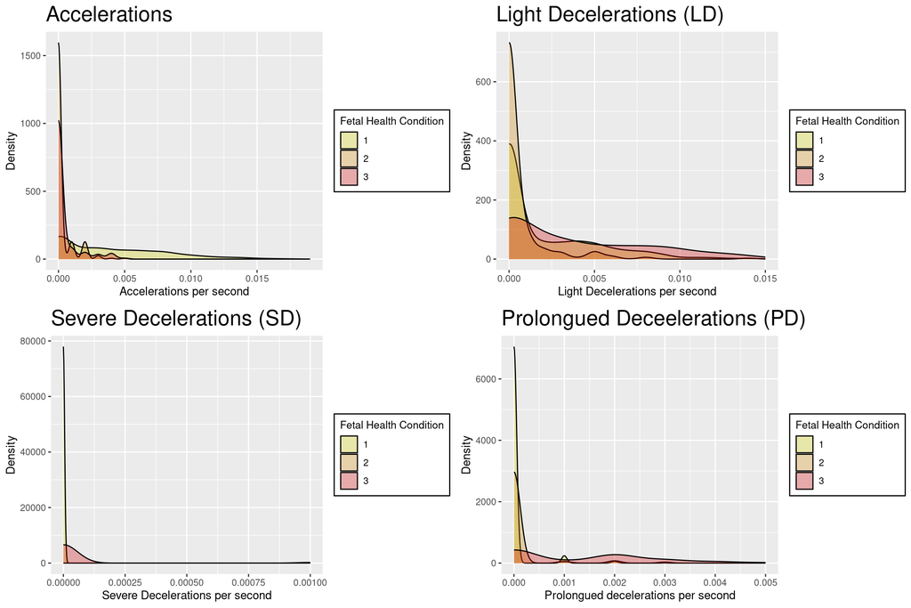

The accelerations and the decelerations often present a different distribution per class. This could be a crucial aspect. In fact, these differences in the distribution can help us modelling our problem, through machine learning methods, as we will discuss in section 4. For what concerns accelerations per second, normal cases are distributed in the range between 0.00 and 0.015. This aspect differs significantly from the other two cases which are distributed around to the value 0. This is expected since, as written before, accelerations are considered to be a reassuring sign for foetal health. The light deceleration distribution is analogous in normal and suspect cases. On the other hand, pathological cases follow a different distribution. The severe decelerations are present only for pathological cases, therefore, the distribution graph is not very eloquent. In conclusion, in the last graph, we can see how the cases are different from each other if we are talking about prolongued decelerations. This could be an important aspect of the detection of a pathological and suspect case.

### 3.3 Foetal and Uterine Movements

The uterus is a hollow organ that provides protective and nutritive support to the ovum from the moment it is fertilized until it grows into a well-developed fetus ready for parturition. Its middle muscular layer is called the myometrium, which is known for its rhythmic contractions which result in ‘endometrial waves’ in the nonpregnant uterus, Braxton Hicks contractions during pregnancy, and true labor towards the end of the third trimester. Labor contractions are painful, regular, and present with a change in cervical dilation and/or effacement. (8) Foetal movements felt by pregnant women are a sign that the foetus is growing in size and strength. The mother is usually the first to feel these movements, which can later be perceived by others. Women are often taught by their health care provider to monitor or be aware of the movements of the foetus. Decreased foetal movement can be a warning sign of potential foetal impairment or risk, and may warrant further evaluation. This activity reviews the evaluation of foetal movement and discusses the role of the interprofessional team in educating patients on how to track foetal movement which can improve patient outcomes.(9)

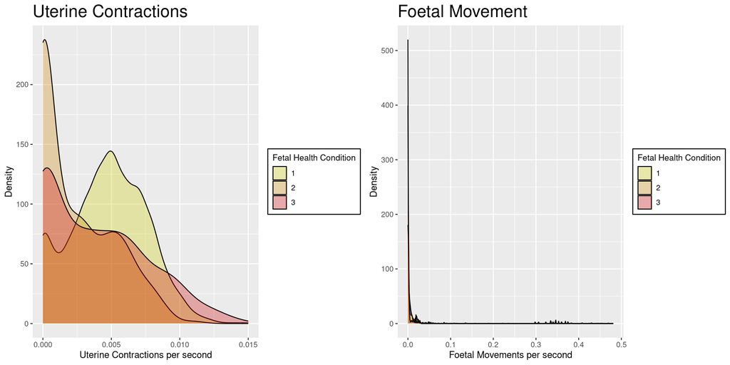

It is possible to notice how, in the uterine contraction graph, the suspect and pathological cases tend to be right-skewed, while the distribution of normal cases seems to be more centred. This is a remarkable aspect that we have to take into account. For what concerns the foetal movements graph, the vast majority of the values are 0 movements per second. In this case, it is very difficult to distinguish between the three classes. However, for any other clarification and graphs, we advise the reader to consult the shiny app that is provided in the dedicated folder.

### 3.4 Short Term Variability VS Long Term Variability

Short Term Variability(STV) is the beat-to-beat variation in foetal heart rate. The CTG monitor calculates STV computerised by dividing every minute of the trace into 16 sections and the average pulse interval is calculated for every section. STV is the mean value of pulse interval differences between sections during one minute and the first value is displayed after 10 min recording. Thereafter new values are added and STV is updated continuously for up to 60 min. (10) Long-term variability is the variations in interval length over a certain number of R-R intervals, clinically expressed as the number of zero crossings, the bandwidth, or the amplitude of frequency changes. (11)

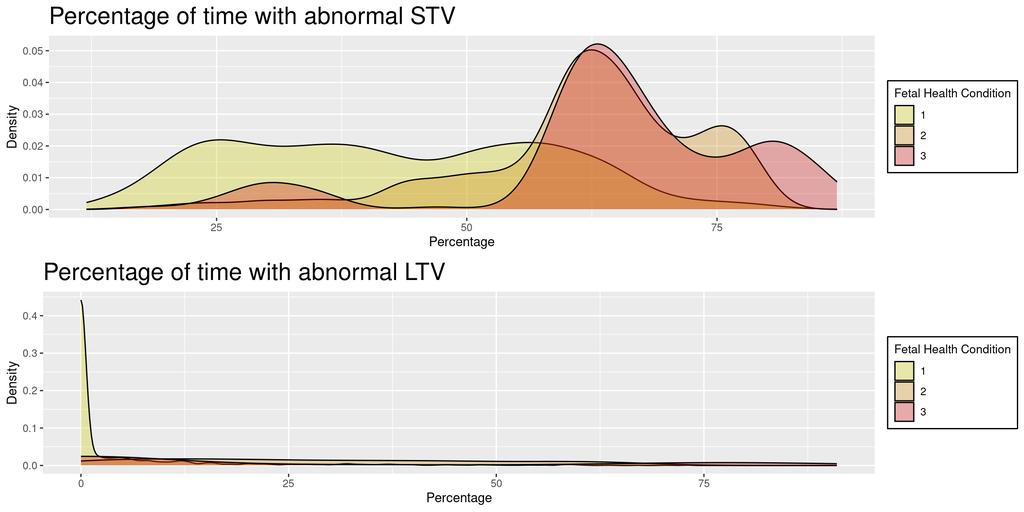

For what concerns STV, the normal cases seem equally distributed (almost a uniform distribution) between the percentages of 10% and 65%. The other two cases tend to be more left-skewed, having the majority of the values enclosed in the range between 55% and 95/100%. The second graph is more complicated to describe. What we believe interesting is the fact that also in this case the normal case distribution differs from the other two. As we said before, all these differences are crucial to create a classification model, even though, most of the time, it is complicated to spot a substantial distinction between pathological and suspect cases.

### 3.5 Heart Rate Histogram

The Heart Rate Histograms is based on the atrial and ventricular event data stored by the device. The Rate Histograms Report presents heart rate data in 3 types of histograms: atrial rate, ventricular rate, and ventricular rate during AT/AF. It also presents data about the patient’s conduction status. (12)

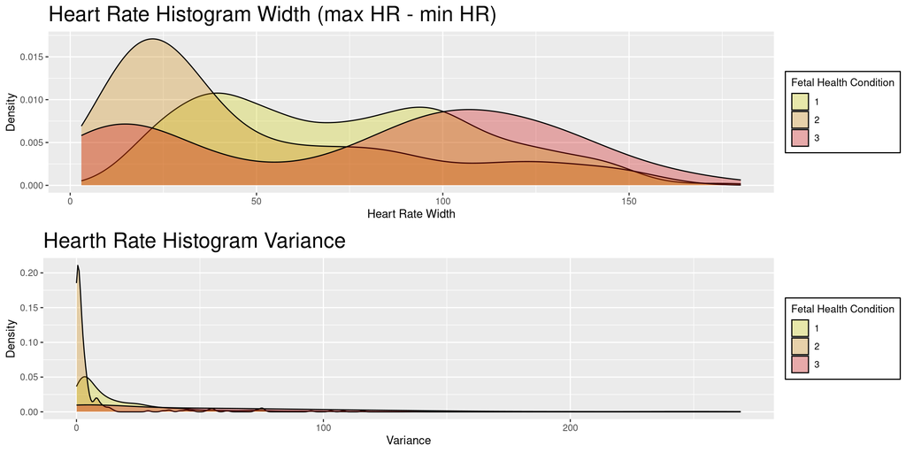

In the graph concerning the histogram width, we can see that the three distribution differs a lot. First of all, the normal cases are fairly evenly distributed across all the recorded values (from 5 to 160). On the contrary, the suspect case distribution seems to be right-skewed, having the majority of the values on the left. The pathological cases present distribution with two marked peaks on the edge. The plot below does not seem much helpful. In fact, our first belief was a strong correlation between foetal health and variance. As the reader can see, it is not the case. However, we are quite sure that the histogram width and variance could assist us in the creation of a classification model due to the fact that the distribution presents several distinctions.

### 3.6 Foetal Health

In this subsection, we would like to evaluate the three categories, to better understand the dataset itself.

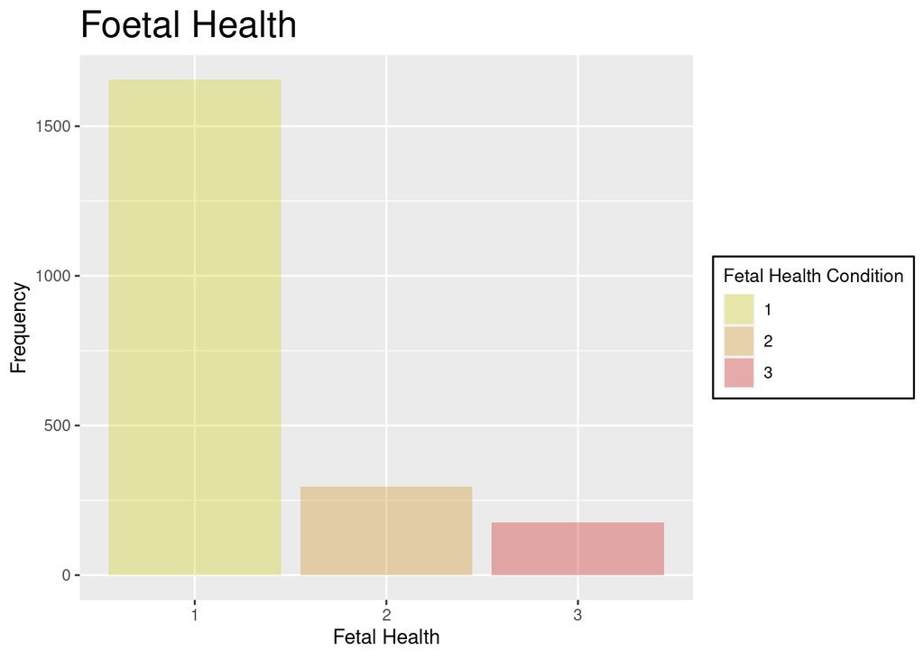

The graph shows the distribution across the three levels (normal, suspect and pathological). The normal class seems to be the most populated, with more than 1600 cases. The other categories (suspect and pathological) have altogether around 500 records. This situation was expected. However, it could cause some technical issues in the classification models.

## 4. Machine Learning Models

In this section we are going to build three different models in order to create predictions. We remind the reader that we do not want our model to substitute in any way professional figures. On the contrary, we aim to create a tool that can assist them in double-checking their diagnosis. We are going to use supervised learning models since our dataset contains already the expected result. Thus, we can just create the model on a training subset of data and test it on another subset. In addition, we would like to inform the reader that we tried to boost ulteriorly the models, using feature selection. In particular, we perform the the rfe function (Recursive Feature Selection) on the data. Unfortunately, the results were not significant as we expected. We, therefore, decided to keep all the 21 variables.

### 4.1 Creation of Test Data and Train Data

The first step is to create a data partition. In fact, data are going to be split into two categories, train and test data. Here is the code used for this purpose.

```r
library(mlbench)
library(kernlab)
library(caret)
library(dplyr)
set.seed(123)
indices <- createDataPartition(df_fetal_health$fetal_health, p = .75, list = F)
train <- df_fetal_health %>% slice(indices)

test_in <- df_fetal_health %>% slice(-indices) %>% select(-fetal_health)
test_in
test_truth <- df_fetal_health %>% slice(-indices) %>% pull(fetal_health)
```

We opted for using the 75% of the data in training models, and the remaining 25% to test them. We also set the partition with the command set.seed since we wanted the reader to be able to reproduce the same experiment.

#### 4.1.1 SVM Model

In machine learning, support vector machines (SVMs, also support vector networks) are supervised learning models with associated learning algorithms that analyze data for classification and regression analysis. (13) The SVM model is performed using two different kernels, linear and radial. We have decided optimal parameters through the function “tune”.

```
## Confusion Matrix and Statistics
##
##           Reference
## Prediction   1   2   3
##          1 391  25   1
##          2  18  45   5
##          3   4   3  38
##
## Overall Statistics
##
##                Accuracy : 0.8943
##                  95% CI : (0.865, 0.9192)
##     No Information Rate : 0.7792
##     P-Value [Acc > NIR] : 3.477e-12
##
##                   Kappa : 0.7083
##
##  Mcnemar's Test P-Value : 0.3287
##
## Statistics by Class:
##
##                      Class: 1 Class: 2 Class: 3
## Sensitivity            0.9467  0.61644  0.86364
## Specificity            0.7778  0.94967  0.98560
## Pos Pred Value         0.9376  0.66176  0.84444
## Neg Pred Value         0.8053  0.93939  0.98763
## Precision              0.9376  0.66176  0.84444
## Recall                 0.9467  0.61644  0.86364
## F1                     0.9422  0.63830  0.85393
## Prevalence             0.7792  0.13774  0.08302
## Detection Rate         0.7377  0.08491  0.07170
## Detection Prevalence   0.7868  0.12830  0.08491
## Balanced Accuracy      0.8623  0.78306  0.92462
```

As we can see, we already have a nice result. To decide about the goodness of the model we look at the F1 score, which is a balanced average between precision and recall. In this case we have extremely precise result for the first and third class (normal = 0.9422 and pathological = 0.85393). As we expected, the suspect cases(F1 = 0.6380) are more difficult to classify (by definition). That is why also the precision and recall are lower compared to the rest. The accuracy is quite significant (accuracy = 0.8943).

```
## Confusion Matrix and Statistics
##
##           Reference
## Prediction   1   2   3
##          1 399  27  16
##          2  14  42   4
##          3   0   4  24
##
## Overall Statistics
##
##                Accuracy : 0.8774
##                  95% CI : (0.8464, 0.9041)
##     No Information Rate : 0.7792
##     P-Value [Acc > NIR] : 4.508e-09
##
##                   Kappa : 0.6285
##
##  Mcnemar's Test P-Value : 0.0001601
##
## Statistics by Class:
##
##                      Class: 1 Class: 2 Class: 3
## Sensitivity            0.9661  0.57534  0.54545
## Specificity            0.6325  0.96061  0.99177
## Pos Pred Value         0.9027  0.70000  0.85714
## Neg Pred Value         0.8409  0.93404  0.96016
## Precision              0.9027  0.70000  0.85714
## Recall                 0.9661  0.57534  0.54545
## F1                     0.9333  0.63158  0.66667
## Prevalence             0.7792  0.13774  0.08302
## Detection Rate         0.7528  0.07925  0.04528
## Detection Prevalence   0.8340  0.11321  0.05283
## Balanced Accuracy      0.7993  0.76798  0.76861
```

In this case, the radial kernel seems to perform slightly worst. In fact, the model has a good precision but there is some problem with the recall. The F1 coefficient are lower, in particular normal F1 = 0.9333, suspect F1 = 0.63158 and pathological F1 = 0.66667. As we can understand, in this case the prediction on the pathological cases are less precise than in the previous model.

#### 4.1.2 Random Forest Classifier Model

Random forests or random decision forests is an ensemble learning method for classification, regression and other tasks that operates by constructing a multitude of decision trees at training time. For classification tasks, the output of the random forest is the class selected by most trees. For regression tasks, the mean or average prediction of the individual trees is returned. (14) In this section we are performing the random forest classifier algorithm. Also in this case we are going to evaluate if the F1 score is significant.

```
## Confusion Matrix and Statistics
##
##           Reference
## Prediction   1   2   3
##          1 400  10   1
##          2  12  62   3
##          3   1   1  40
##
## Overall Statistics
##
##                Accuracy : 0.9472
##                  95% CI : (0.9245, 0.9646)
##     No Information Rate : 0.7792
##     P-Value [Acc > NIR] : <2e-16
##
##                   Kappa : 0.8569
##
##  Mcnemar's Test P-Value : 0.7574
##
## Statistics by Class:
##
##                      Class: 1 Class: 2 Class: 3
## Sensitivity            0.9685   0.8493  0.90909
## Specificity            0.9060   0.9672  0.99588
## Pos Pred Value         0.9732   0.8052  0.95238
## Neg Pred Value         0.8908   0.9757  0.99180
## Precision              0.9732   0.8052  0.95238
## Recall                 0.9685   0.8493  0.90909
## F1                     0.9709   0.8267  0.93023
## Prevalence             0.7792   0.1377  0.08302
## Detection Rate         0.7547   0.1170  0.07547
## Detection Prevalence   0.7755   0.1453  0.07925
## Balanced Accuracy      0.9373   0.9082  0.95249
```

#### 4.1.3 Multinomial Logistic Regression Model

In statistics, multinomial logistic regression is a classification method that generalizes logistic regression to multiclass problems, i.e. with more than two possible discrete outcomes. (15) We decided to perform a multinomial logistic regression to classify the possible foetal health status. This is the case since we are dealing with a multiclass problem (1,2,3 are the factors).

```
## Confusion Matrix and Statistics
##
##           Reference
## Prediction   1   2   3
##          1 379  17   2
##          2  28  51   8
##          3   6   5  34
##
## Overall Statistics
##
##                Accuracy : 0.8755
##                  95% CI : (0.8443, 0.9024)
##     No Information Rate : 0.7792
##     P-Value [Acc > NIR] : 9.146e-09
##
##                   Kappa : 0.6767
##
##  Mcnemar's Test P-Value : 0.1459
##
## Statistics by Class:
##
##                      Class: 1 Class: 2 Class: 3
## Sensitivity            0.9177  0.69863  0.77273
## Specificity            0.8376  0.92123  0.97737
## Pos Pred Value         0.9523  0.58621  0.75556
## Neg Pred Value         0.7424  0.95034  0.97938
## Precision              0.9523  0.58621  0.75556
## Recall                 0.9177  0.69863  0.77273
## F1                     0.9346  0.63750  0.76404
## Prevalence             0.7792  0.13774  0.08302
## Detection Rate         0.7151  0.09623  0.06415
## Detection Prevalence   0.7509  0.16415  0.08491
## Balanced Accuracy      0.8776  0.80993  0.87505
```

## 5. Conclusion

### 5.1 Answer to the project’s question

At the beginning of our study, we questioned ourselves about two important aspects:

1. “Can we create a model to classify and predict foetal health, based on CTG results?”
2. “In case the answer to the first question was affirmative, can the obtained model be used as a tool to assist doctors and obstetricians to prevent child and maternal mortality?”

The first answer is quite obvious. We can create a model base on CTG data. Or, better yet, we can find several models that can be used for the same purpose. For what concerns the second question, the situation is quite different. We cannot be sure that these tools can help professional figures, such as doctors and obstetricians to double-check their diagnosis, although the models are pretty accurate. Therefore, we are planning to contact some expert to understand what is the real potential of this study.

### 5.2 Possible implementations for the future

As written in the last paragraph, we would like to show the project to a professional to measure how useful these models can be. We believe that there are also other two aspects to consider:

1. we need to understand if it is possible to gather data in the form that we have in this study, with the same columns and measure units.
2. we would like to know more about the class division, we would be able to answer the question “how do doctors define the suspect cases?”.

We believe that future implementation of these models can be based on these aspects. The first one is crucial to limit costs. Gathering data that are already in the CTG machine is cheap. However, we do not know if every CTG machine can display all these data. Therefore, if we cannot have all the data we cannot further implement the model. For what concerns the class division, the main problem is that the diagnosis is based on doctor skills and subjective analysis. Thus, we would like to understand the common criteria and the differences between healthcare professionals in this topic, and, if possible, modelling this information, implementing what we have reached.

### 5.3 Shiny App

We developed a Shiny App to show the result most interactively. You can find all the data in the opposite folder. The idea is to provide the reader with an easy and dynamic tool to make quick predictions.

## Sources

Below the reader can find all the sources and references:

1. https://data.unicef.org/topic/child-survival/under-five-mortality/
2. https://www.who.int/news-room/fact-sheets/detail/maternal-mortality
3. https://www.ncbi.nlm.nih.gov/books/NBK557393/
4. https://pubmed.ncbi.nlm.nih.gov/11874624/
5. https://www.kaggle.com/datasets/andrewmvd/fetal-health-classification
6. https://www.sciencedirect.com/topics/nursing-and-health-professions/fetus-heart-rate
7. https://www.aafp.org/pubs/afp/issues/1999/0501/p2487.html
8. https://www.ncbi.nlm.nih.gov/books/NBK532927/
9. https://www.ncbi.nlm.nih.gov/books/NBK470566/
10. https://bmcpregnancychildbirth.biomedcentral.com/articles/10.1186/s12884-016-0845-8
11. https://link.springer.com/chapter/10.1007/978-3-642-70358-4_20
12. https://www.medtronicacademy.com/features/rate-histograms-feature
13. https://en.wikipedia.org/wiki/Support_vector_machine
14. https://en.wikipedia.org/wiki/Random_forest